# Wine Quality by Nicolas Veiga

This report explores a dataset containg 1599 observations about wine. The goal of this document is apply Exploratory data analysis(EDA) tecniques learned on the course(Data Analyst Nanodegree, module 6).

The dataset that is goin to be explored is the Red Wine Quality dataset, link for the dataset can be found course material.

The goal of the exploration is to find with attributes contribute the most for the quality of the Wine. That sad, we can expect that most of the exploration is going to involve the attribute Quality and other variables.

Attribute information:

For more information, read [Cortez et al., 2009].

Input variables (based on physicochemical tests): 1 - fixed acidity (tartaric acid - g / dm^3) 2 - volatile acidity (acetic acid - g / dm^3) 3 - citric acid (g / dm^3) 4 - residual sugar (g / dm^3) 5 - chlorides (sodium chloride - g / dm^3 6 - free sulfur dioxide (mg / dm^3) 7 - total sulfur dioxide (mg / dm^3) 8 - density (g / cm^3) 9 - pH 10 - sulphates (potassium sulphate - g / dm3) 11 - alcohol (% by volume) Output variable (based on sensory data): 12 - quality (score between 0 and 10)

Description of attributes:

1 - fixed acidity: most acids involved with wine or fixed or nonvolatile (do not evaporate readily)

2 - volatile acidity: the amount of acetic acid in wine, which at too high of levels can lead to an unpleasant, vinegar taste

3 - citric acid: found in small quantities, citric acid can add ‘freshness’ and flavor to wines

4 - residual sugar: the amount of sugar remaining after fermentation stops, it’s rare to find wines with less than 1 gram/liter and wines with greater than 45 grams/liter are considered sweet

5 - chlorides: the amount of salt in the wine

6 - free sulfur dioxide: the free form of SO2 exists in equilibrium between molecular SO2 (as a dissolved gas) and bisulfite ion; it prevents microbial growth and the oxidation of wine

7 - total sulfur dioxide: amount of free and bound forms of S02; in low concentrations, SO2 is mostly undetectable in wine, but at free SO2 concentrations over 50 ppm, SO2 becomes evident in the nose and taste of wine

8 - density: the density of water is close to that of water depending on the percent alcohol and sugar content

9 - pH: describes how acidic or basic a wine is on a scale from 0 (very acidic) to 14 (very basic); most wines are between 3-4 on the pH scale

10 - sulphates: a wine additive which can contribute to sulfur dioxide gas (S02) levels, wich acts as an antimicrobial and antioxidant

11 - alcohol: the percent alcohol content of the wine

Output variable (based on sensory data): 12 - quality (score between 0 and 10)

### Basic statistics and information about the dataset:

Name of the attributes:

```
##  [1] "X"                    "fixed.acidity"        "volatile.acidity"
##  [4] "citric.acid"          "residual.sugar"       "chlorides"
##  [7] "free.sulfur.dioxide"  "total.sulfur.dioxide" "density"
## [10] "pH"                   "sulphates"            "alcohol"
## [13] "quality"
```

How the attributes presents themselves:

```
## 'data.frame':    1599 obs. of  13 variables:
##  $ X                   : int  1 2 3 4 5 6 7 8 9 10 ...
##  $ fixed.acidity       : num  7.4 7.8 7.8 11.2 7.4 7.4 7.9 7.3 7.8 7.5 ...
##  $ volatile.acidity    : num  0.7 0.88 0.76 0.28 0.7 0.66 0.6 0.65 0.58 0.5 ...
##  $ citric.acid         : num  0 0 0.04 0.56 0 0 0.06 0 0.02 0.36 ...
##  $ residual.sugar      : num  1.9 2.6 2.3 1.9 1.9 1.8 1.6 1.2 2 6.1 ...
##  $ chlorides           : num  0.076 0.098 0.092 0.075 0.076 0.075 0.069 0.065 0.073 0.071 ...
##  $ free.sulfur.dioxide : num  11 25 15 17 11 13 15 15 9 17 ...
##  $ total.sulfur.dioxide: num  34 67 54 60 34 40 59 21 18 102 ...
##  $ density             : num  0.998 0.997 0.997 0.998 0.998 ...
##  $ pH                  : num  3.51 3.2 3.26 3.16 3.51 3.51 3.3 3.39 3.36 3.35 ...
##  $ sulphates           : num  0.56 0.68 0.65 0.58 0.56 0.56 0.46 0.47 0.57 0.8 ...
##  $ alcohol             : num  9.4 9.8 9.8 9.8 9.4 9.4 9.4 10 9.5 10.5 ...
##  $ quality             : int  5 5 5 6 5 5 5 7 7 5 ...
```

We can see that actually we have 13 variables instead of 12 as reported above. The attribute X only represents the number of the observation, so it is the same as line count, what can be ignore. 11 attributes are numerics and only one, quality, is integer. Summary of the data:

```
##        X          fixed.acidity   volatile.acidity  citric.acid
##  Min.   :   1.0   Min.   : 4.60   Min.   :0.1200   Min.   :0.000
##  1st Qu.: 400.5   1st Qu.: 7.10   1st Qu.:0.3900   1st Qu.:0.090
##  Median : 800.0   Median : 7.90   Median :0.5200   Median :0.260
##  Mean   : 800.0   Mean   : 8.32   Mean   :0.5278   Mean   :0.271
##  3rd Qu.:1199.5   3rd Qu.: 9.20   3rd Qu.:0.6400   3rd Qu.:0.420
##  Max.   :1599.0   Max.   :15.90   Max.   :1.5800   Max.   :1.000
##  residual.sugar     chlorides       free.sulfur.dioxide
##  Min.   : 0.900   Min.   :0.01200   Min.   : 1.00
##  1st Qu.: 1.900   1st Qu.:0.07000   1st Qu.: 7.00
##  Median : 2.200   Median :0.07900   Median :14.00
##  Mean   : 2.539   Mean   :0.08747   Mean   :15.87
##  3rd Qu.: 2.600   3rd Qu.:0.09000   3rd Qu.:21.00
##  Max.   :15.500   Max.   :0.61100   Max.   :72.00
##  total.sulfur.dioxide    density             pH          sulphates
##  Min.   :  6.00       Min.   :0.9901   Min.   :2.740   Min.   :0.3300
##  1st Qu.: 22.00       1st Qu.:0.9956   1st Qu.:3.210   1st Qu.:0.5500
##  Median : 38.00       Median :0.9968   Median :3.310   Median :0.6200
##  Mean   : 46.47       Mean   :0.9967   Mean   :3.311   Mean   :0.6581
##  3rd Qu.: 62.00       3rd Qu.:0.9978   3rd Qu.:3.400   3rd Qu.:0.7300
##  Max.   :289.00       Max.   :1.0037   Max.   :4.010   Max.   :2.0000
##     alcohol         quality
##  Min.   : 8.40   Min.   :3.000
##  1st Qu.: 9.50   1st Qu.:5.000
##  Median :10.20   Median :6.000
##  Mean   :10.42   Mean   :5.636
##  3rd Qu.:11.10   3rd Qu.:6.000
##  Max.   :14.90   Max.   :8.000
```

# Univariate Plots Section

In this section we are going to be exploring each attribute, its distribution and some statistics so we can have a more insight about the data.

### Fixed acidity

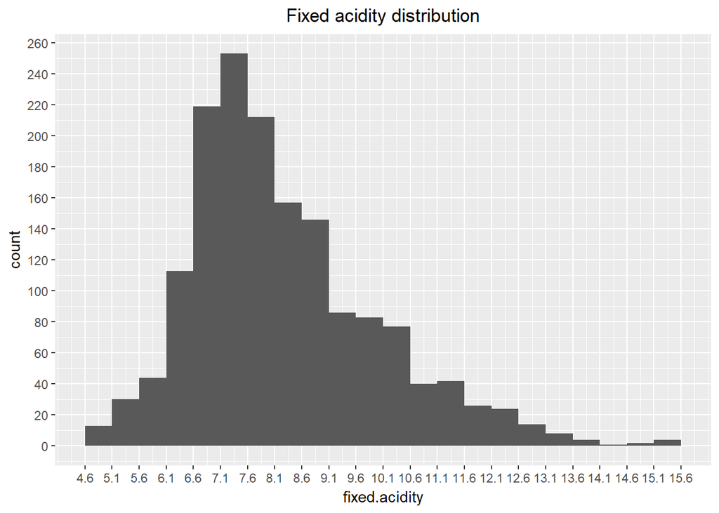

```
## [1] 4.6
```

```
##    Min. 1st Qu.  Median    Mean 3rd Qu.    Max.
##    4.60    7.10    7.90    8.32    9.20   15.90
```

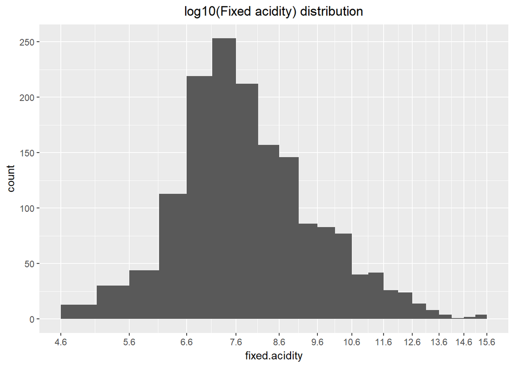

### Volatile acidity

```
##    Min. 1st Qu.  Median    Mean 3rd Qu.    Max.
##  0.1200  0.3900  0.5200  0.5278  0.6400  1.5800
```

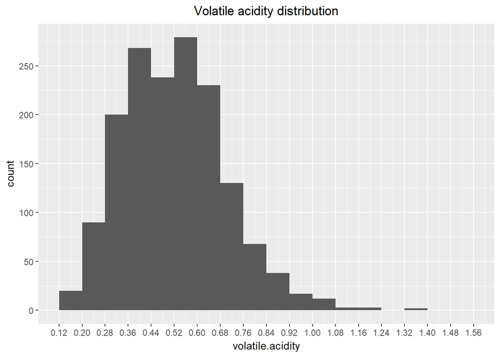

Volatile acidity has very close median and mean values, that means it has a normal distribution. It is possible to see by the graph that it may be a good idea to remove some outliers when comparing against other variables.

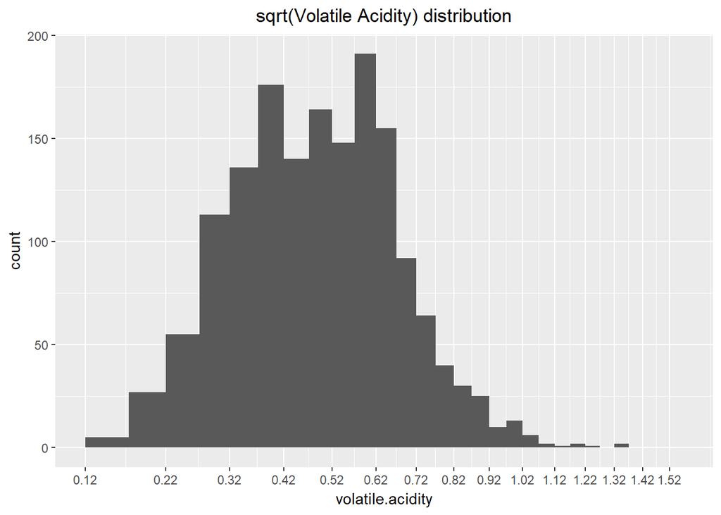

Volatile acidity does not takes a lot of advantage of transforming its scale because it already has a notmal distribution. The difference is on the outliers when we transform the variable, we can notice that the amount of outliers reduces because all distributions shifts to the right when the scale is transformed.

### Citric acid

```
##    Min. 1st Qu.  Median    Mean 3rd Qu.    Max.
##   0.000   0.090   0.260   0.271   0.420   1.000
```

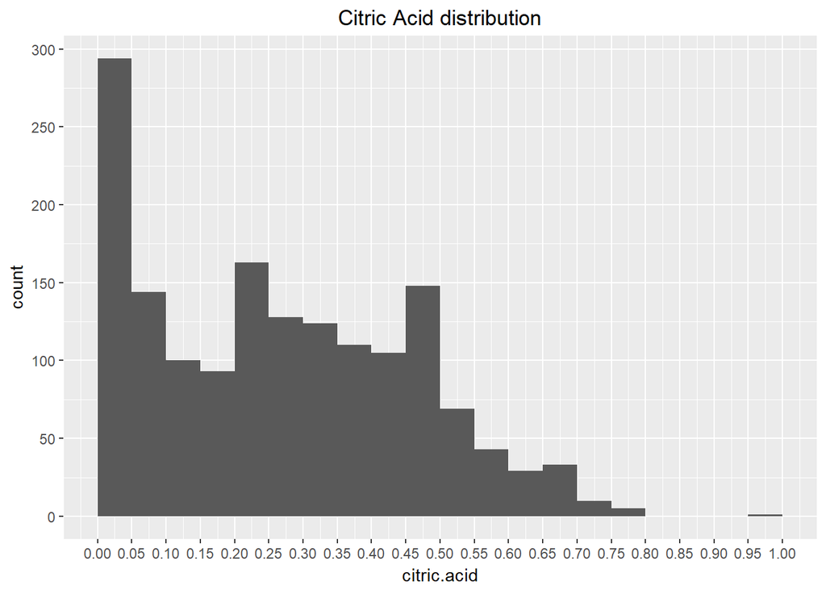

It seens to have a lot of values equal to 0. Lets cound them:

```
##
## FALSE  TRUE
##  1467   132
```

Citric Acid distribution is almost constant from 0 to 0.5 and starts to decrease from 0,5 to 0,75. The peak of the distribution is 0 with 132 occurences.

### Residual sugar

```
##    Min. 1st Qu.  Median    Mean 3rd Qu.    Max.
##   0.900   1.900   2.200   2.539   2.600  15.500
```

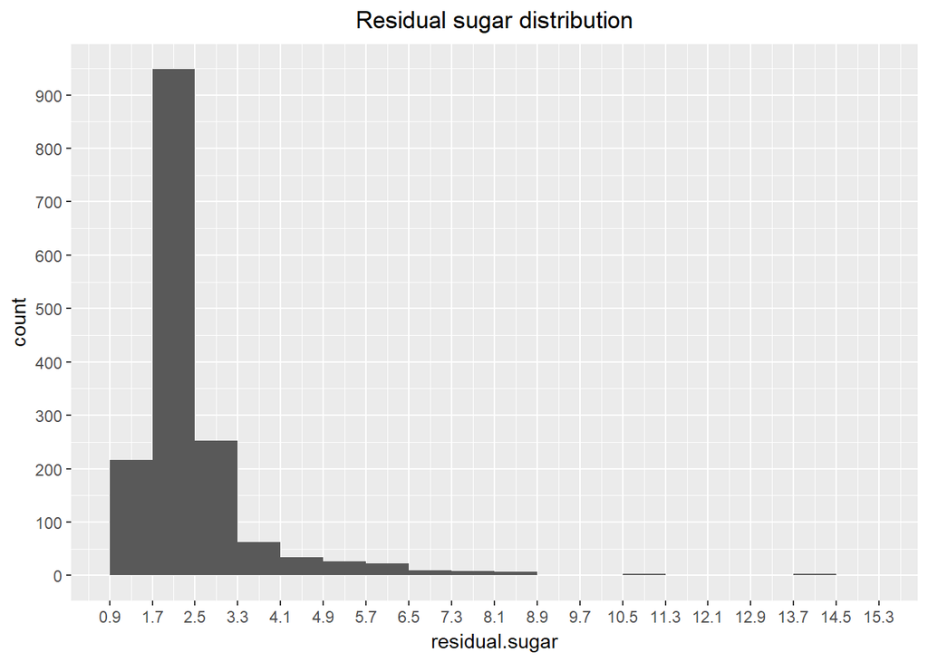

Residual sugar has a skewed distribution to the right and it also has a lot of outliers. When using this variable, transforming its scale and removing outliers may return better results when computing correlation.

### Chlorides

```
##    Min. 1st Qu.  Median    Mean 3rd Qu.    Max.
## 0.01200 0.07000 0.07900 0.08747 0.09000 0.61100
```

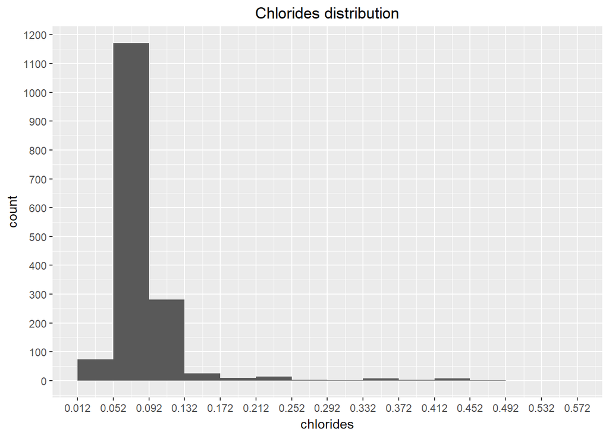

Chlorides has a skewed distribution to the right (mean > median), we also notice that it has some outliers. This outliers can influence when computing the correlation against other variables, they are going to be removed by selecting the percentile of the data.

### free sulfur dioxide

```
##    Min. 1st Qu.  Median    Mean 3rd Qu.    Max.
##    1.00    7.00   14.00   15.87   21.00   72.00
```

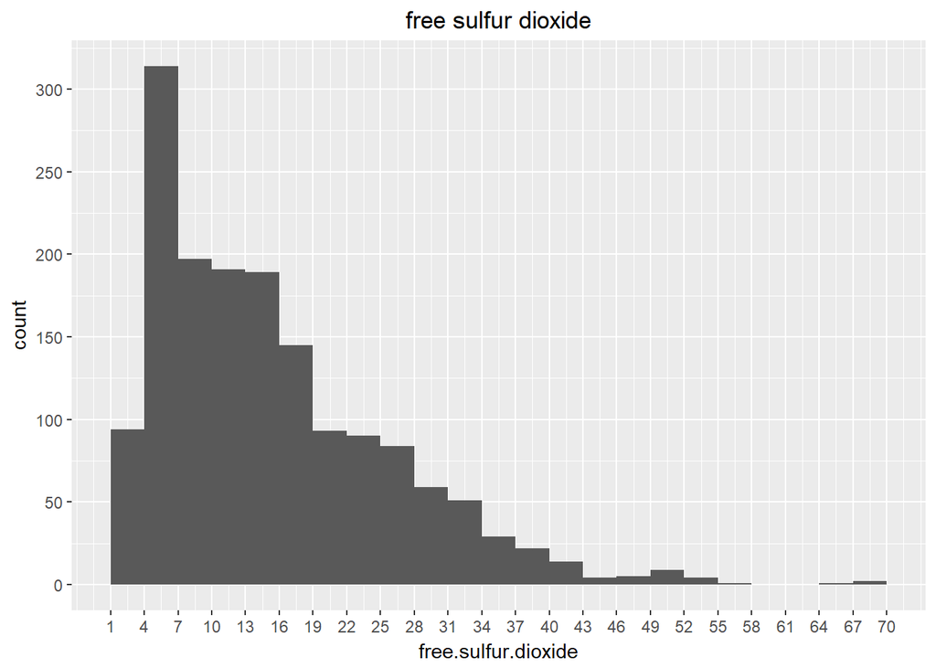

The free surfur dioxide present the same caracteristics as the variables already investigated. It has a skewed distribution to the right and some outliers.

### total sulfur dioxide

```
##    Min. 1st Qu.  Median    Mean 3rd Qu.    Max.
##    6.00   22.00   38.00   46.47   62.00  289.00
```

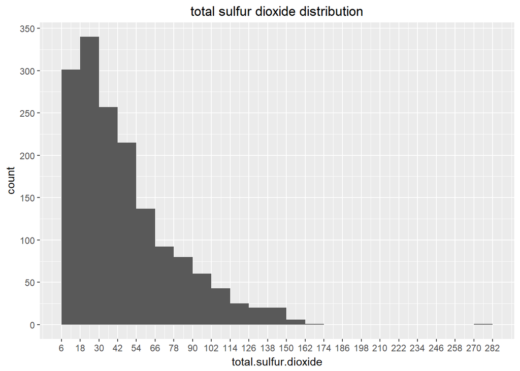

Total sulfur dioxide distribution also is skewed to the right and contains some outliers.

### density

```
##    Min. 1st Qu.  Median    Mean 3rd Qu.    Max.
##  0.9901  0.9956  0.9968  0.9967  0.9978  1.0037
```

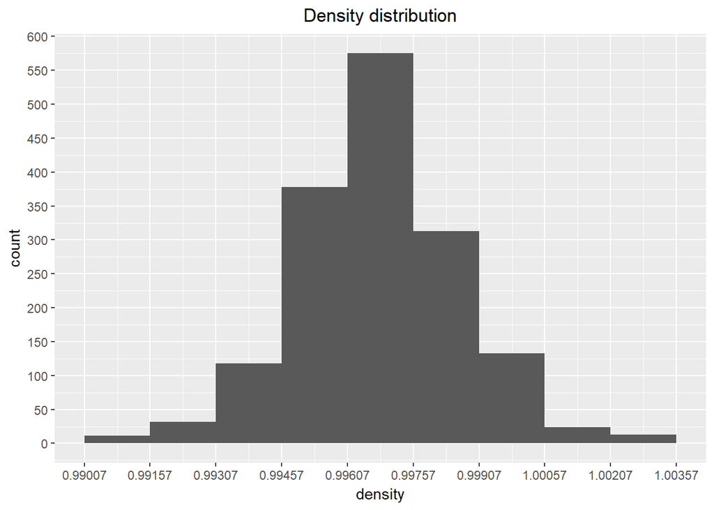

Density distribution is normal where mean is very similar to the median. Median - Mean = 0.0001 where density ranges from 0.9901 to 1.0037.

### pH

```
##    Min. 1st Qu.  Median    Mean 3rd Qu.    Max.
##   2.740   3.210   3.310   3.311   3.400   4.010
```

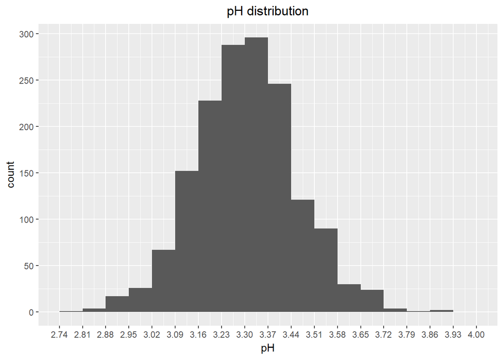

pH distribution has a normal distribution, mean - median is equals 0.001 in a range that goes from 2.740 to 4.010.

### sulphates

```
##    Min. 1st Qu.  Median    Mean 3rd Qu.    Max.
##  0.3300  0.5500  0.6200  0.6581  0.7300  2.0000
```

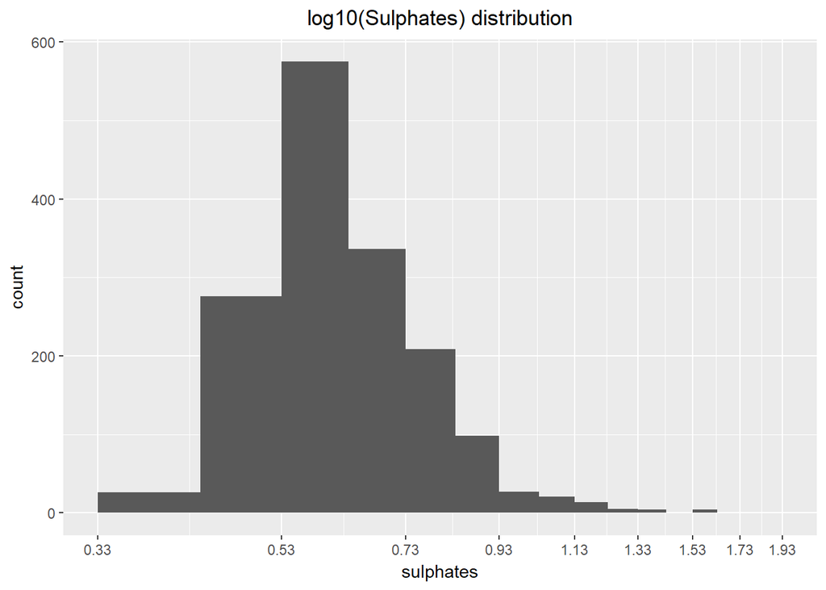

Sulphates has a skewed distribution to the right and also some outliers. The scale was modified using log10 transform.

### Alcohol

```
##    Min. 1st Qu.  Median    Mean 3rd Qu.    Max.
##    8.40    9.50   10.20   10.42   11.10   14.90
```

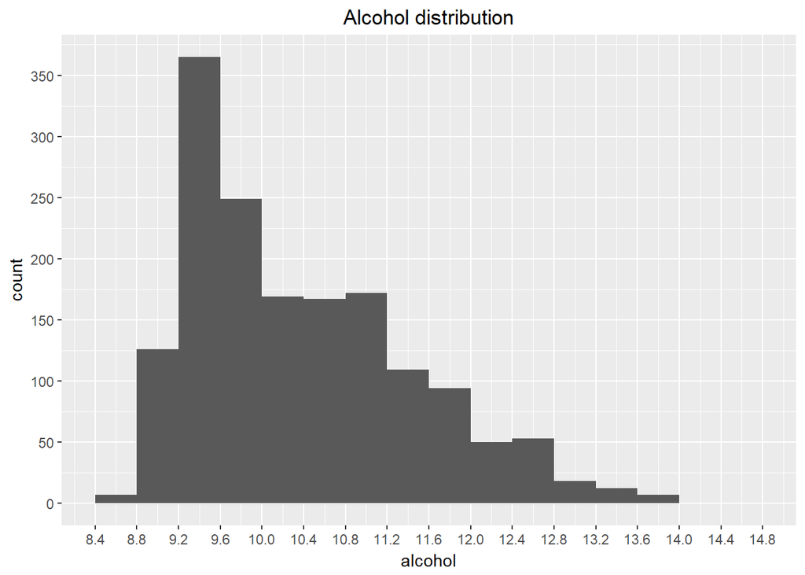

### Quality

Since Quality is going to be explored as a categorical variable, we are going to convert it to factor.

```
##   3   4   5   6   7   8
##  10  53 681 638 199  18
```

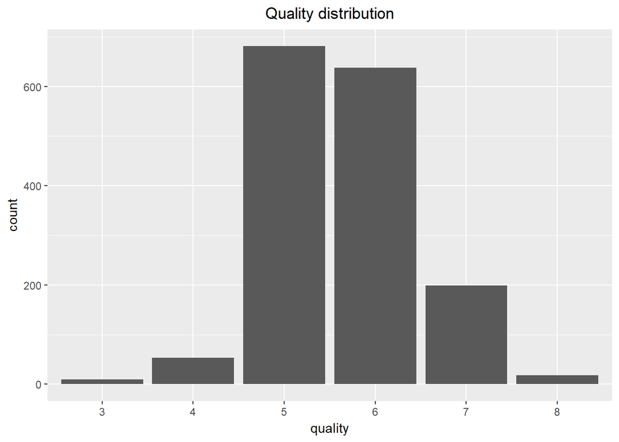

From this graph we notice that quality ranges from 3 to 8, and most of the data is between 5 and 7.

# Univariate Analysis

### What is the structure of your dataset?

There is 1599 wine avalations in the dataset with 12 features. Eleven features are numerics and one is discret, that is Quality. Quality is an integer attibute that can go from 0 to 10. Most of the wines were evaluated as 5 and 6, there was no wine evaluated below 3 and no wine was above 8.

### What is/are the main feature(s) of interest in your dataset?

Main variable is quality. The main goal is to evaluate quality agains the other variables to see what makes a wine have a better quality.

### What other features in the dataset do you think will help support your investigation into your feature(s) of interest?

From the discription of each feature and my understand of it, all can influence the taste except quality.

### Did you create any new variables from existing variables in the dataset?

No other variables was created.

### Of the features you investigated, were there any unusual distributions? Did you perform any operations on the data to tidy, adjust, or change the form of the data? If so, why did you do this?

Some scale transformations were performed to give us better visualization of the distributions. We used a log10 transformation for sulphates because most of the data was grouped forming a skewed distribution to the right. That may also help when computing the Pearsons correlation with other variable that has a normal distribution. We also used sqrt transformation for volatile acidity and log10 on fixed acidity for the same reason.

# Bivariate Plots Section

The main goal of this section is going to be to explore the attribute QUality agains other attributes. Also to have a idea on how the variables behave when explored agains each other.

Also we are going to compute the correlation between all variables, the goal is to find if any pair of variable has an hight correlation so we can create a linear model to help us classify the wine.

Computing pearsons correlation between each variable, we are going to remove the variable “X” from the dataset because it does not add anything to us.

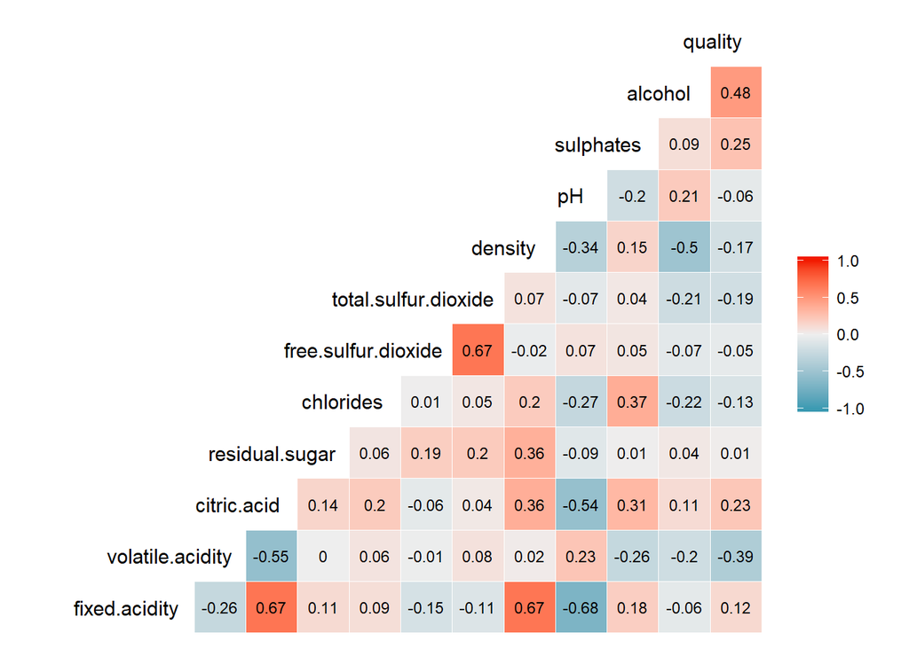

```r
cor(wine_quality_2)
```

```
##                      fixed.acidity volatile.acidity citric.acid
## fixed.acidity           1.00000000     -0.256130895  0.67170343
## volatile.acidity       -0.25613089      1.000000000 -0.55249568
## citric.acid             0.67170343     -0.552495685  1.00000000
## residual.sugar          0.11477672      0.001917882  0.14357716
## chlorides               0.09370519      0.061297772  0.20382291
## free.sulfur.dioxide    -0.15379419     -0.010503827 -0.06097813
## total.sulfur.dioxide   -0.11318144      0.076470005  0.03553302
## density                 0.66804729      0.022026232  0.36494718
## pH                     -0.68297819      0.234937294 -0.54190414
## sulphates               0.18300566     -0.260986685  0.31277004
## alcohol                -0.06166827     -0.202288027  0.10990325
## quality                 0.12405165     -0.390557780  0.22637251
##                      residual.sugar    chlorides free.sulfur.dioxide
## fixed.acidity           0.114776724  0.093705186        -0.153794193
## volatile.acidity        0.001917882  0.061297772        -0.010503827
## citric.acid             0.143577162  0.203822914        -0.060978129
## residual.sugar          1.000000000  0.055609535         0.187048995
## chlorides               0.055609535  1.000000000         0.005562147
## free.sulfur.dioxide     0.187048995  0.005562147         1.000000000
## total.sulfur.dioxide    0.203027882  0.047400468         0.667666450
## density                 0.355283371  0.200632327        -0.021945831
## pH                     -0.085652422 -0.265026131         0.070377499
## sulphates               0.005527121  0.371260481         0.051657572
## alcohol                 0.042075437 -0.221140545        -0.069408354
## quality                 0.013731637 -0.128906560        -0.050656057
##                      total.sulfur.dioxide     density          pH
## fixed.acidity                 -0.11318144  0.66804729 -0.68297819
## volatile.acidity               0.07647000  0.02202623  0.23493729
## citric.acid                    0.03553302  0.36494718 -0.54190414
## residual.sugar                 0.20302788  0.35528337 -0.08565242
## chlorides                      0.04740047  0.20063233 -0.26502613
## free.sulfur.dioxide            0.66766645 -0.02194583  0.07037750
## total.sulfur.dioxide           1.00000000  0.07126948 -0.06649456
## density                        0.07126948  1.00000000 -0.34169933
## pH                            -0.06649456 -0.34169933  1.00000000
## sulphates                      0.04294684  0.14850641 -0.19664760
## alcohol                       -0.20565394 -0.49617977  0.20563251
## quality                       -0.18510029 -0.17491923 -0.05773139
##                         sulphates     alcohol     quality
## fixed.acidity         0.183005664 -0.06166827  0.12405165
## volatile.acidity     -0.260986685 -0.20228803 -0.39055778
## citric.acid           0.312770044  0.10990325  0.22637251
## residual.sugar        0.005527121  0.04207544  0.01373164
## chlorides             0.371260481 -0.22114054 -0.12890656
## free.sulfur.dioxide   0.051657572 -0.06940835 -0.05065606
## total.sulfur.dioxide  0.042946836 -0.20565394 -0.18510029
## density               0.148506412 -0.49617977 -0.17491923
## pH                   -0.196647602  0.20563251 -0.05773139
## sulphates             1.000000000  0.09359475  0.25139708
## alcohol               0.093594750  1.00000000  0.47616632
## quality               0.251397079  0.47616632  1.00000000
```

Very little correlation between the variables, the highest is 0.67.

### Quality versus fixed acidity

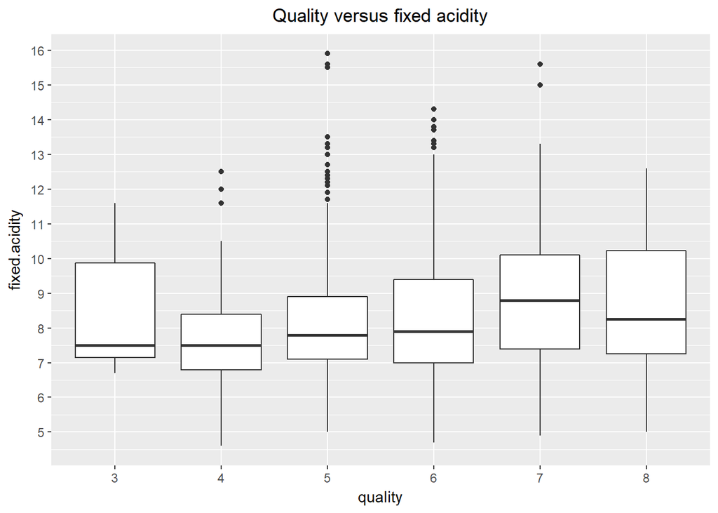

### Quality versus volatice acidity

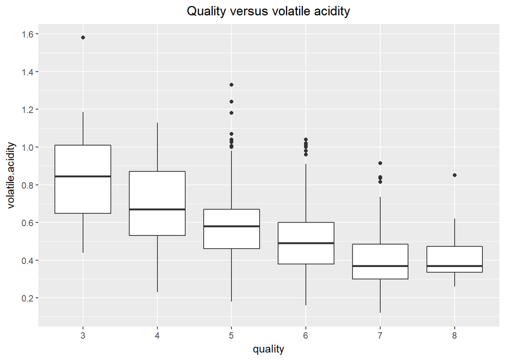

The graph Quality versus volatile acidity is a little better, we can see that lower volatile acidity means better wine. For instance between qualities 5, 6 and 7 the mean decreases as we increase quality, for quality 5 the mean is a little below 0.6, quality 6 the mean is below 0.5 and quality 7 the mean is below 0.4.

### Quality versus citric acid

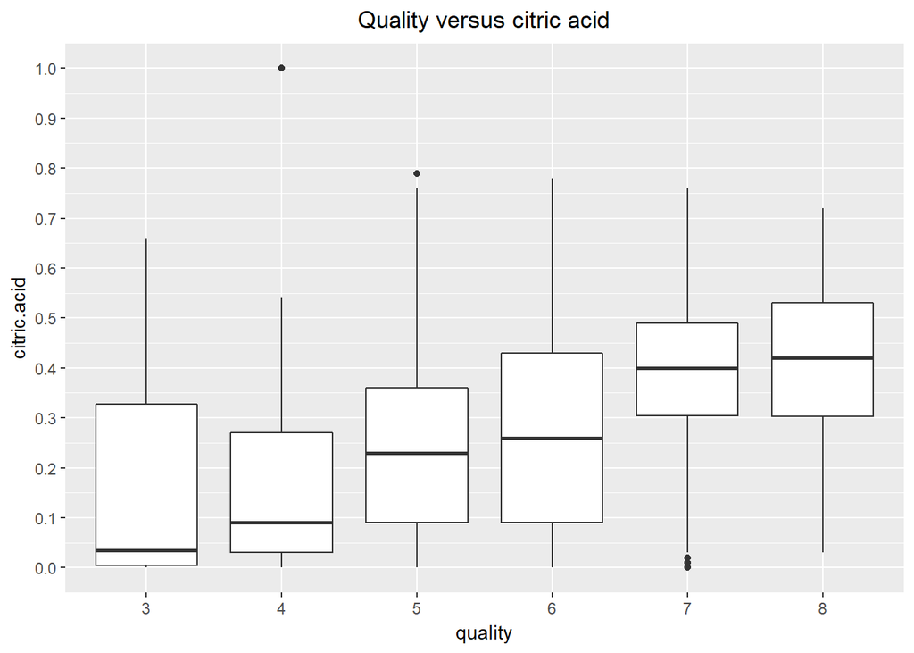

Quality versus citric acid also gives us that highest the citric acid better the wine. The difference for the mean between qualities 5 and 6 are lower than 0.1 citric acid, quality 5 is below 0.25 and for quality 6 is above 0.25, quality 7 has a mean of 0.4 citric acid. We need to take care about this one because once most of the data is in the range of quality between 5 and 7, the data from quality equals to 3, 4 and 8 may be misleading. When looking only to 5 and 6, the two categories that we have more data, the mean does not change that much, but it changes a lot from 6 to 7 even thought most of the citric acid range from quality 7 is in the range of 50% - 75% percentile from quality equals to 6. I would not count with this attribute.

### Quality versus residual sugar.

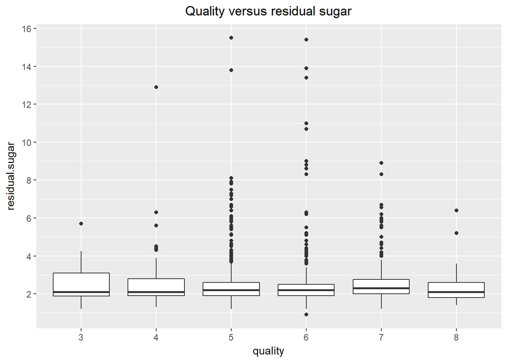

```
## wine_quality$quality: 3
##    Min. 1st Qu.  Median    Mean 3rd Qu.    Max.
##   1.200   1.875   2.100   2.635   3.100   5.700
## --------------------------------------------------------
## wine_quality$quality: 4
##    Min. 1st Qu.  Median    Mean 3rd Qu.    Max.
##   1.300   1.900   2.100   2.694   2.800  12.900
## --------------------------------------------------------
## wine_quality$quality: 5
##    Min. 1st Qu.  Median    Mean 3rd Qu.    Max.
##   1.200   1.900   2.200   2.529   2.600  15.500
## --------------------------------------------------------
## wine_quality$quality: 6
##    Min. 1st Qu.  Median    Mean 3rd Qu.    Max.
##   0.900   1.900   2.200   2.477   2.500  15.400
## --------------------------------------------------------
## wine_quality$quality: 7
##    Min. 1st Qu.  Median    Mean 3rd Qu.    Max.
##   1.200   2.000   2.300   2.721   2.750   8.900
## --------------------------------------------------------
## wine_quality$quality: 8
##    Min. 1st Qu.  Median    Mean 3rd Qu.    Max.
##   1.400   1.800   2.100   2.578   2.600   6.400
```

### Quality versus chlorides

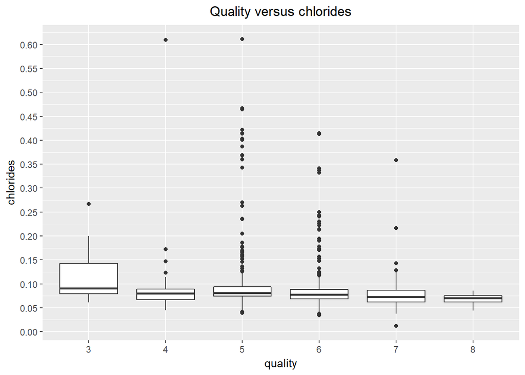

Chlorides presents a small diference between categories 5, 6 and 7. Lets take a closer look:

```
## wine_quality$quality: 3
##    Min. 1st Qu.  Median    Mean 3rd Qu.    Max.
##  0.0610  0.0790  0.0905  0.1225  0.1430  0.2670
## --------------------------------------------------------
## wine_quality$quality: 4
##    Min. 1st Qu.  Median    Mean 3rd Qu.    Max.
## 0.04500 0.06700 0.08000 0.09068 0.08900 0.61000
## --------------------------------------------------------
## wine_quality$quality: 5
##    Min. 1st Qu.  Median    Mean 3rd Qu.    Max.
## 0.03900 0.07400 0.08100 0.09274 0.09400 0.61100
## --------------------------------------------------------
## wine_quality$quality: 6
##    Min. 1st Qu.  Median    Mean 3rd Qu.    Max.
## 0.03400 0.06825 0.07800 0.08496 0.08800 0.41500
## --------------------------------------------------------
## wine_quality$quality: 7
##    Min. 1st Qu.  Median    Mean 3rd Qu.    Max.
## 0.01200 0.06200 0.07300 0.07659 0.08700 0.35800
## --------------------------------------------------------
## wine_quality$quality: 8
##    Min. 1st Qu.  Median    Mean 3rd Qu.    Max.
## 0.04400 0.06200 0.07050 0.06844 0.07550 0.08600
```

Only considering the categories where quality is equal to 5,6 and 7, we can see that the median and mean decreases on wines that have better quality. The average are 0.09274, 0.08496 and 0.07659 for qualities 5, 6 and 7 respectively.

### Quality versus free sulfur dioxide

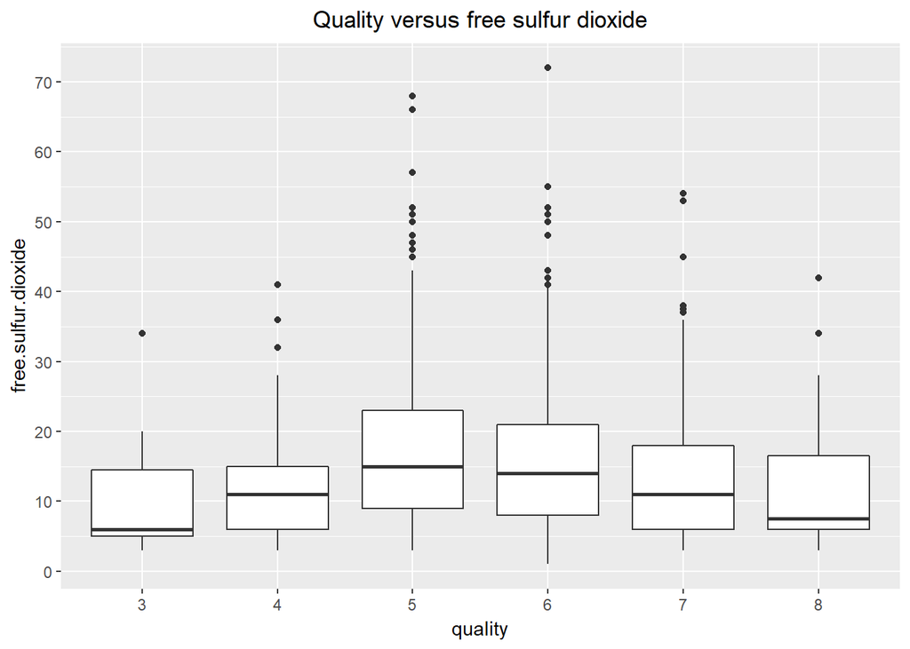

Even thought free sulfur dioxide appears to have no pattern, when looking only for quality equals to 5, 6 and 7 we notice that lower the free sulfur dioxide better the wine. Looking at the data below qualities 5,6 and 7 have an average of 16.98, 15.71 and 14.05 respectively.

```
## wine_quality$quality: 3
##    Min. 1st Qu.  Median    Mean 3rd Qu.    Max.
##     3.0     5.0     6.0    11.0    14.5    34.0
## --------------------------------------------------------
## wine_quality$quality: 4
##    Min. 1st Qu.  Median    Mean 3rd Qu.    Max.
##    3.00    6.00   11.00   12.26   15.00   41.00
## --------------------------------------------------------
## wine_quality$quality: 5
##    Min. 1st Qu.  Median    Mean 3rd Qu.    Max.
##    3.00    9.00   15.00   16.98   23.00   68.00
## --------------------------------------------------------
## wine_quality$quality: 6
##    Min. 1st Qu.  Median    Mean 3rd Qu.    Max.
##    1.00    8.00   14.00   15.71   21.00   72.00
## --------------------------------------------------------
## wine_quality$quality: 7
##    Min. 1st Qu.  Median    Mean 3rd Qu.    Max.
##    3.00    6.00   11.00   14.05   18.00   54.00
## --------------------------------------------------------
## wine_quality$quality: 8
##    Min. 1st Qu.  Median    Mean 3rd Qu.    Max.
##    3.00    6.00    7.50   13.28   16.50   42.00
```

### Quality versus total sulfur dioxide

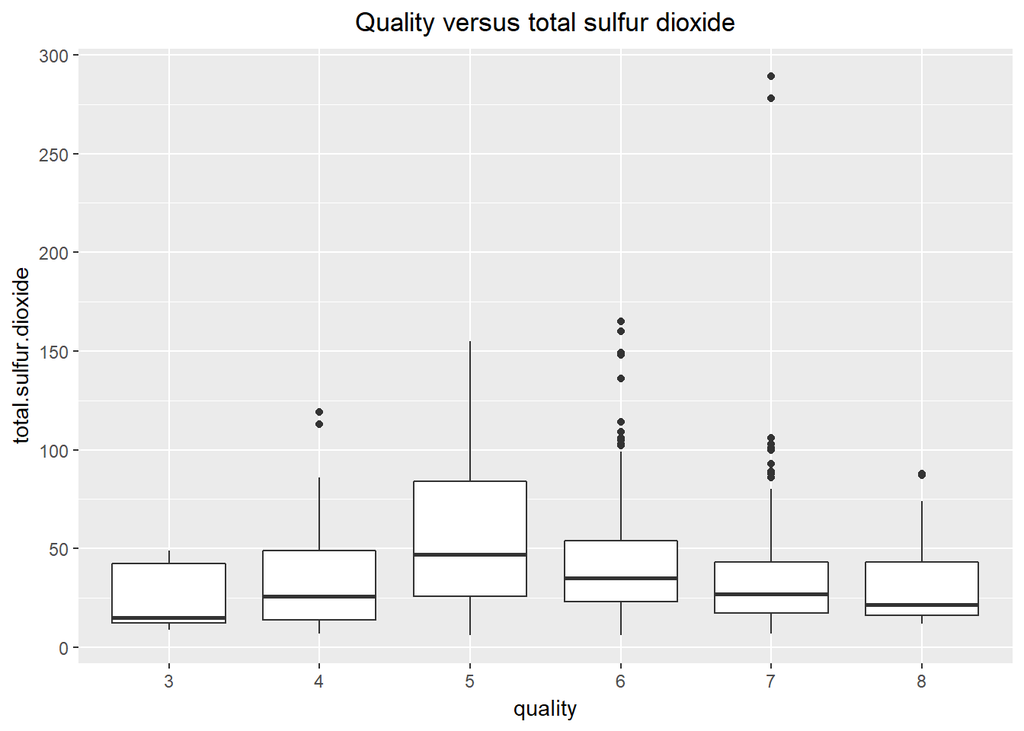

Same behavior as free sulfur dioxide. Mean and median decreases as the quality of the wine increases. The mean for qualities 5,6 and 7 are 56.51, 40.87 and 35.02 respectively.

```
## wine_quality$quality: 3
##    Min. 1st Qu.  Median    Mean 3rd Qu.    Max.
##     9.0    12.5    15.0    24.9    42.5    49.0
## --------------------------------------------------------
## wine_quality$quality: 4
##    Min. 1st Qu.  Median    Mean 3rd Qu.    Max.
##    7.00   14.00   26.00   36.25   49.00  119.00
## --------------------------------------------------------
## wine_quality$quality: 5
##    Min. 1st Qu.  Median    Mean 3rd Qu.    Max.
##    6.00   26.00   47.00   56.51   84.00  155.00
## --------------------------------------------------------
## wine_quality$quality: 6
##    Min. 1st Qu.  Median    Mean 3rd Qu.    Max.
##    6.00   23.00   35.00   40.87   54.00  165.00
## --------------------------------------------------------
## wine_quality$quality: 7
##    Min. 1st Qu.  Median    Mean 3rd Qu.    Max.
##    7.00   17.50   27.00   35.02   43.00  289.00
## --------------------------------------------------------
## wine_quality$quality: 8
##    Min. 1st Qu.  Median    Mean 3rd Qu.    Max.
##   12.00   16.00   21.50   33.44   43.00   88.00
```

### QUality versus density

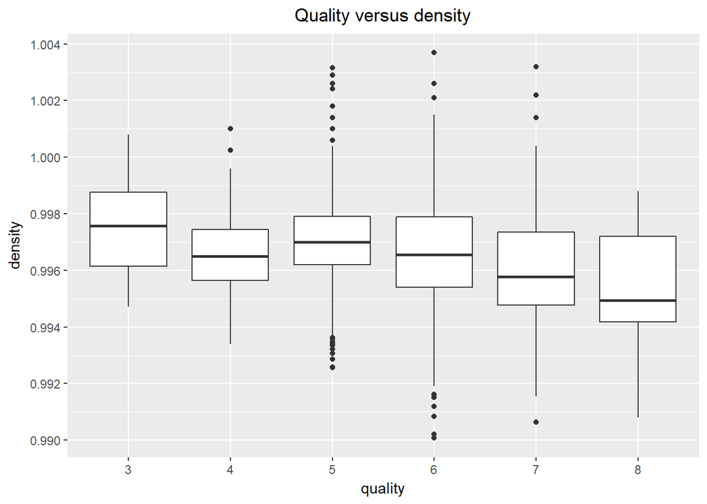

Density is a variable that may not help, lower the density means better the wine but there is no difference between qualities 5 and 6, the averages are lower but 25% - 75% of the data from quality 5 has the same values as quality 6, that means when plotted agains another variable, density is not going to help distinguish these categories.

### Quality versus pH

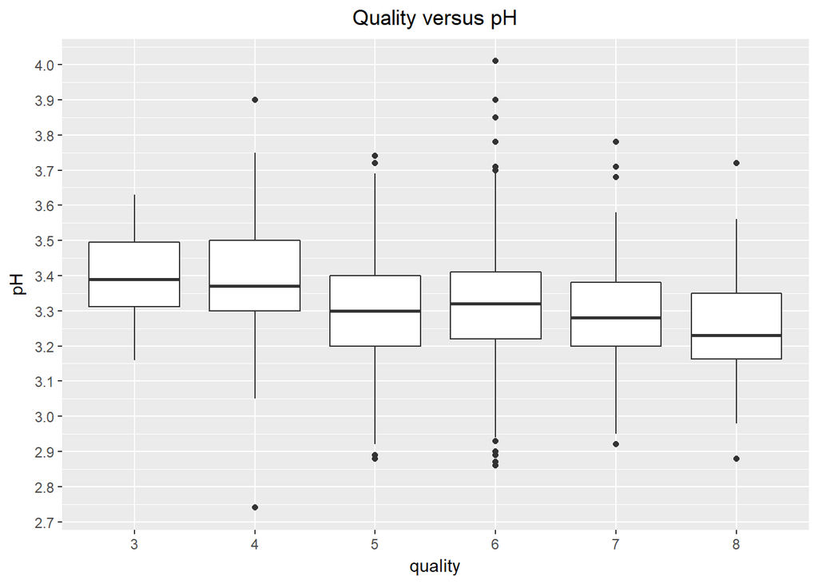

pH is another variable that may not help by the graph. When taking in consideration classes 5, 6 and 7, pH increases from 5 to 6 but decreases from 6 to 7. That tell us that pH is not a good variable for differenciation between the wines.

### Quality versus sulphates

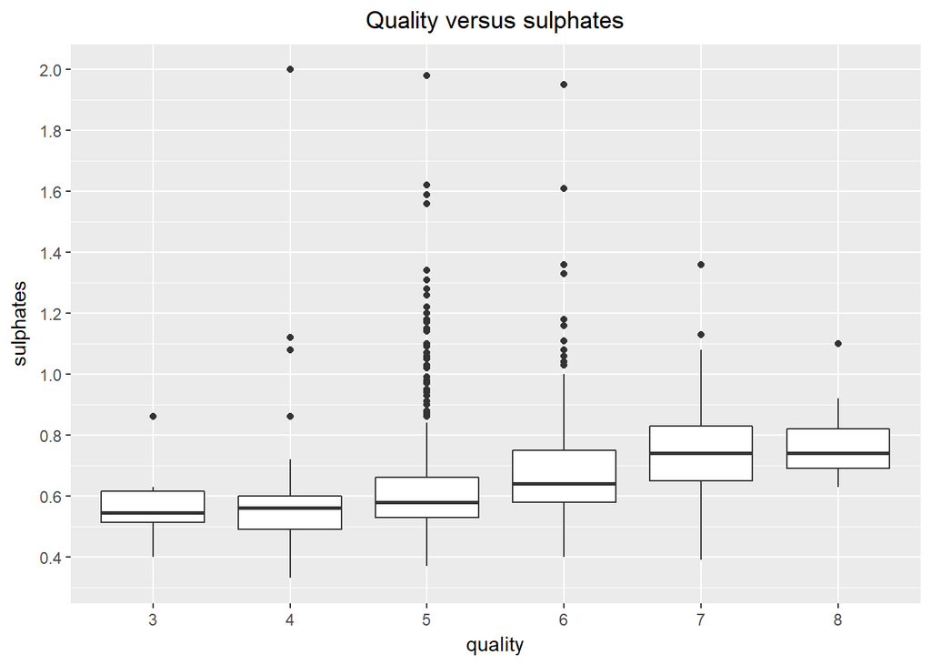

Sulphates is an attribute that can help in distinguishing between the wines. The boundaries are not well defined but we definitely can see that better wines have more sulphates. For quality 5 we have a mean around 0.6, quality 6 has a mean around 0.65 and quality 7 has a mean around 0.75.

### Quality versus alcohol

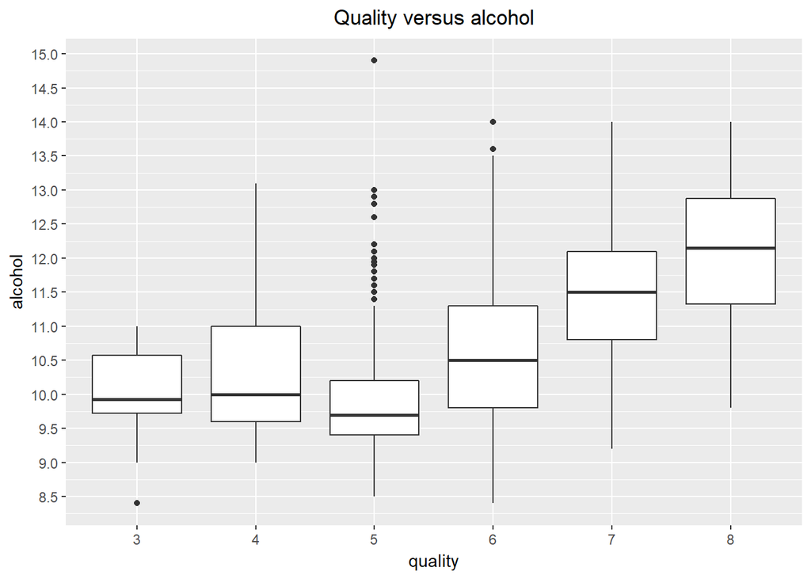

Alcohol may be the best variable so far. It is the best variable because it is the one that shows the largest difference between classes 5, 6 and 7. When looking at the chart, wines with higher percentages of alcohol are classified as better wines. Quality 5, 6 and 7 have mean of 9.75, 10.5 and 11.5 respectively.

### Exploring the highest correlations

Exploring this relationship is helpfull because when we add quality as a third parameter, we may be able to classify quality using a linear model.

#### Citric acid versus fixed acidity

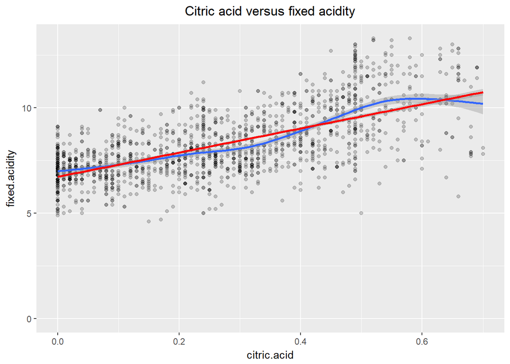

```
##
##  Pearson's product-moment correlation
##
## data:  citric.acid and fixed.acidity
## t = 36.234, df = 1597, p-value < 2.2e-16
## alternative hypothesis: true correlation is greater than 0
## 95 percent confidence interval:
##  0.648478 1.000000
## sample estimates:
##       cor
## 0.6717034
```

Fixed acidity versus citric acid appears to have a weak linear relationship. The data is spreaded out and the pattern along the x axes has a sine pattern. For instance the blue line, that is a pattern from each point, starts above the red line, that is a linear model approximated from the data and stays that way from 0.0 until 0.1 that is when the blue line starts to go below the red line, meaning that it has more points in this region. Also the distance from the blue line to the red starts to increase along the x axes what means that the data gets more uneven for high values of citric acid.

#### Free sulfur dioxide versus total sulfur dioxide

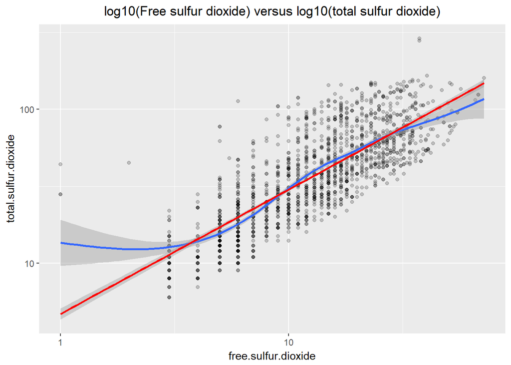

```
##
##  Pearson's product-moment correlation
##
## data:  log10(free.sulfur.dioxide) and log10(total.sulfur.dioxide)
## t = 50.575, df = 1597, p-value < 2.2e-16
## alternative hypothesis: true correlation is greater than 0
## 95 percent confidence interval:
##  0.7682774 1.0000000
## sample estimates:
##       cor
## 0.7846217
```

Total sulfur dioxide versus free surfur dioxide had almost 0,8 correlation. Both scales where modified using a log10 transform, what makes the distribution more compact in the middle of the chart, giving the imprecion of a cluster. In this central region, the data behaves almost as a linear model, but that does not happen in the extremeties of the chart, where the blue line gets far from the red line.

#### density versus fixed acidity

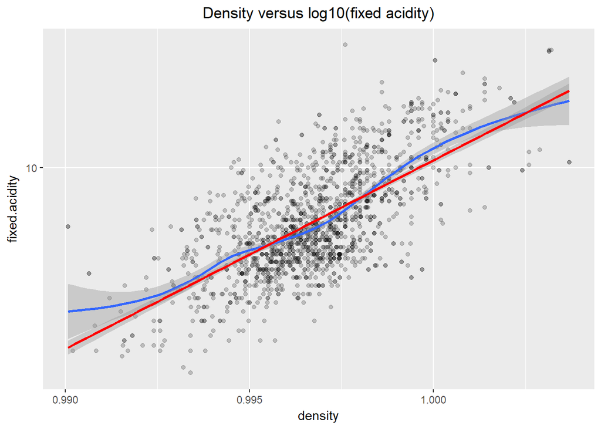

```
##
##  Pearson's product-moment correlation
##
## data:  density and log(fixed.acidity)
## t = 34.704, df = 1583, p-value < 2.2e-16
## alternative hypothesis: true correlation is greater than 0
## 95 percent confidence interval:
##  0.6332006 1.0000000
## sample estimates:
##       cor
## 0.6573288
```

Density versus fixed acidity have a correlation of 0,657. Fixed acidity had its scale modified with a log10 scale. The distribution resembles a cluster, in the middle of the distribution we can find some correlation between the variables but when we move from the center the data gets spreaded.

#### pH versus fixed acidity

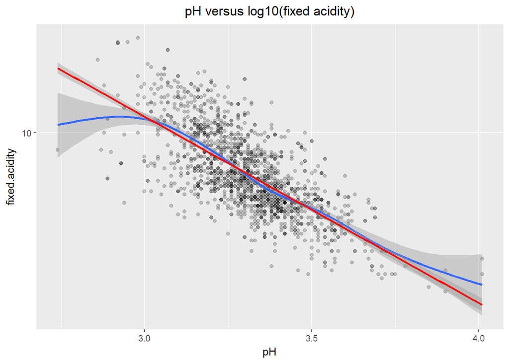

```
##
##  Pearson's product-moment correlation
##
## data:  pH and log10(fixed.acidity)
## t = -38.414, df = 1583, p-value = 1
## alternative hypothesis: true correlation is greater than 0
## 95 percent confidence interval:
##  -0.7153812  1.0000000
## sample estimates:
##        cor
## -0.6945873
```

pH versus fixed acidity. Fixed acidity had its scale modified using a log10 transformation. The distribution has a negative correlation of -0,694. It is to possible notice that the blue line is close to the red line in the middle of the distribution, where the data is more dense but it gets separated in the regions with less data points.

# Bivariate Analysis

### Talk about some of the relationships you observed in this part of the investigation. How did the feature(s) of interest vary with other features in the dataset?

Plotting all variables against quality, we figure out that there is some attributes that their variation does not influence on quality. We can notice that from the box plot quality versus fixed acidity, residual sugar and pH. For all the other attributes, quality is influenced by them but their distribution is tight to multiple quality categories. That means the boundaries that separete categories are not clear. In most of the cases more them 25% of the data is in the frontier. All that is considering that quality ranges from 5 to 7, that is because the other categories have little amount of samples.

The more promissing variables is alcohol, because is the one where we can see more differences between the categories and also has the smallest percentage of samples that falls into other categories, less than 25%.

### Did you observe any interesting relationships between the other features (not the main feature(s) of interest)?

Exploring the attributes with the highest correlations, we notice that some correlations could be improved when using some transformation. We can use this information together with Quality in a attempt of finding some pattern that explains why some wine are better.

Citric acidity versus fixed acidity both are very bad when explored agains Quality independently, so I do not expect anything from this graph. It is only a correlation between two variables that does not help. Free sulfur dioxide versus total sulfur dioxide looks promissing because both presents some distinguishment when compaed agains Quality. Density versus fixed acidity and pH versus fixed acidity are just higher correlations that does not help. All their attributes correlates poorly with Quality.

### What was the strongest relationship you found?

The strongest relationship is Quality versus Alcohol.

# Multivariate Plots Section

### Free sulfur dioxide versus Total sulfur dioxide versus Quality

Since we are mostly looking for Quality in the range of 5 to 7, we are going to subset the dataset only for this values.

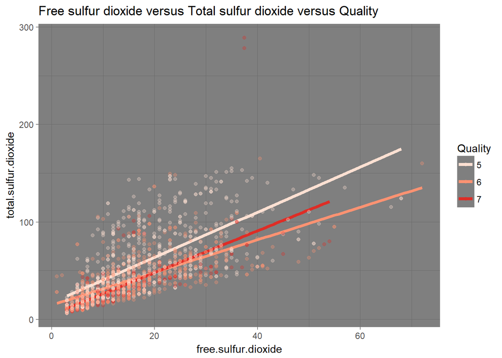

In the chart above we can notice that quality 5 is grouped just above quality 6, that is also possible to notice by the linear aproximation of the distribution. The linear approximation for quality 7 is in the middle of linear approximation for qualities 5 and 6, that is because the data that belongs to the wines with quality equals to 7 is more spreaded out in the graph. One conclusion that we can take from this graph is that wines with better quality have lower total sulfur dioxide, also is not possible to distinguish between qualities 6 and 7, so I would say that they have similar values for both variables. All the conclusion can be supported by charts from the section bivariate plots section.